# Estimación de Resultados

Socializacion de la Participación política: familia y escuela

Daniel Miranda, Julio Iturra, Brian Montenegro & Karen Sepúlveda

# Se cargan los paquetes necesarios para el Análisis Multinivel y se carga la BDD

# Se genera base de datos con N fijado

```r
#str(data)
#names(data)
#View(data)
#table(data$P45, data$educ_apod)
#data$pad_libros <- recode(data$pad_libros, "c(4,5)=4")
#table (data$pad_libros, data$P47)

data_red <- data %>%
 # dplyr::mutate(quintil=quintiles_ingresos_pc_factor)%>%
#  dplyr::group_by(RBDE)%>% # Agrupa los datos
#  dplyr::mutate(meancivico=mean(civico, na.rm = TRUE)) %>% # crea promedio para cada escuela
#  dplyr::mutate(meanap=mean(apertura, na.rm = TRUE)) %>% # crea promedio para cada escuela
#  ungroup() %>% # Desagrupa
#  dplyr::mutate(civico_gc=civico-meancivico)%>% # Crea variavble centrada al grupo (escuela)
#  dplyr::mutate(apertura_gc=apertura-meanap)%>% # Crea variavble centrada al grupo (escuela)
  dplyr::select(formal,
                                disruptivo,
                                nodisruptivo,
                                act_marcha,
                                voto_apod,
                                educ_apod,
                                pad_libros,
                                conversacion,
                                apertura,
                                civico,
                                #quintil,
                                sexo,
                                dependencia,
                                region,
                                RBDE, meancivico, meanap, civico_gc, apertura_gc) %>% na.omit

#str(data_red)
#names(data_red)
```

# Modelos nulos

Se generan los modelos nulos para cada una de las variables dependientes (Participación formal, participación disruptiva y participación no disruptiva). Luego se generan los resúmenes de los modelos nulos.

```
## Linear mixed model fit by REML ['lmerMod']
## Formula: formal ~ (1 | RBDE)
##    Data: data_red
##
## REML criterion at convergence: 728.4
##
## Scaled residuals:
##      Min       1Q   Median       3Q      Max
## -3.01185 -0.01104  0.23423  0.50968  2.13530
##
## Random effects:
##  Groups   Name        Variance Std.Dev.
##  RBDE     (Intercept) 0.01717  0.131
##  Residual             0.22088  0.470
## Number of obs: 524, groups:  RBDE, 60
##
## Fixed effects:
##             Estimate Std. Error t value
## (Intercept) -0.13346    0.02849  -4.684
```

```
## Linear mixed model fit by REML ['lmerMod']
## Formula: nodisruptivo ~ (1 | RBDE)
##    Data: data_red
##
## REML criterion at convergence: 235.5
##
## Scaled residuals:
##     Min      1Q  Median      3Q     Max
## -1.9798 -0.7152 -0.3541  0.6687  3.4056
##
## Random effects:
##  Groups   Name        Variance Std.Dev.
##  RBDE     (Intercept) 0.01474  0.1214
##  Residual             0.08261  0.2874
## Number of obs: 524, groups:  RBDE, 60
##
## Fixed effects:
##             Estimate Std. Error t value
## (Intercept)  0.04042    0.02157   1.874
```

```
## Linear mixed model fit by REML ['lmerMod']
## Formula: disruptivo ~ (1 | RBDE)
##    Data: data_red
##
## REML criterion at convergence: 907.1
##
## Scaled residuals:
##     Min      1Q  Median      3Q     Max
## -1.9512 -0.6893 -0.3008  0.5530  3.6344
##
## Random effects:
##  Groups   Name        Variance Std.Dev.
##  RBDE     (Intercept) 0.06498  0.2549
##  Residual             0.29444  0.5426
## Number of obs: 524, groups:  RBDE, 60
##
## Fixed effects:
##             Estimate Std. Error t value
## (Intercept)  0.13302    0.04346   3.061
```

Correlación intraclase. Es un valor que oscila entre 0 (sin variación entre grupos) y 1 (variación entre grupos pero sin variación dentro de los grupos).

```r
0.01717/(0.01717+0.221) #Formal
```

```
## [1] 0.07209136
```

```r
0.01474/(0.01474+0.08261) #Participación no disrruptiva
```

```
## [1] 0.1514124
```

```r
0.06498/(0.06498+0.2944) #Participación disrruptiva
```

```
## [1] 0.1808114
```

Visualización de efectos aleatorios

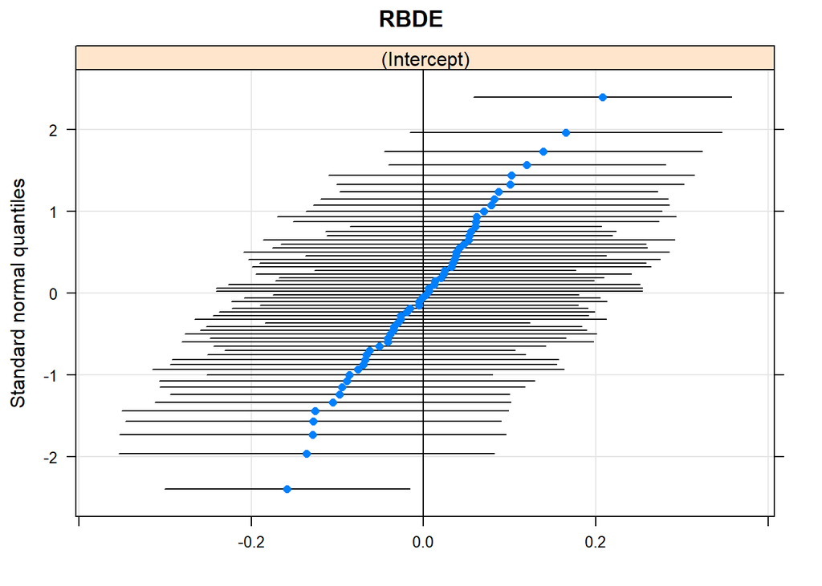

```r
qqmath(ranef(m001, condVar = TRUE))
```

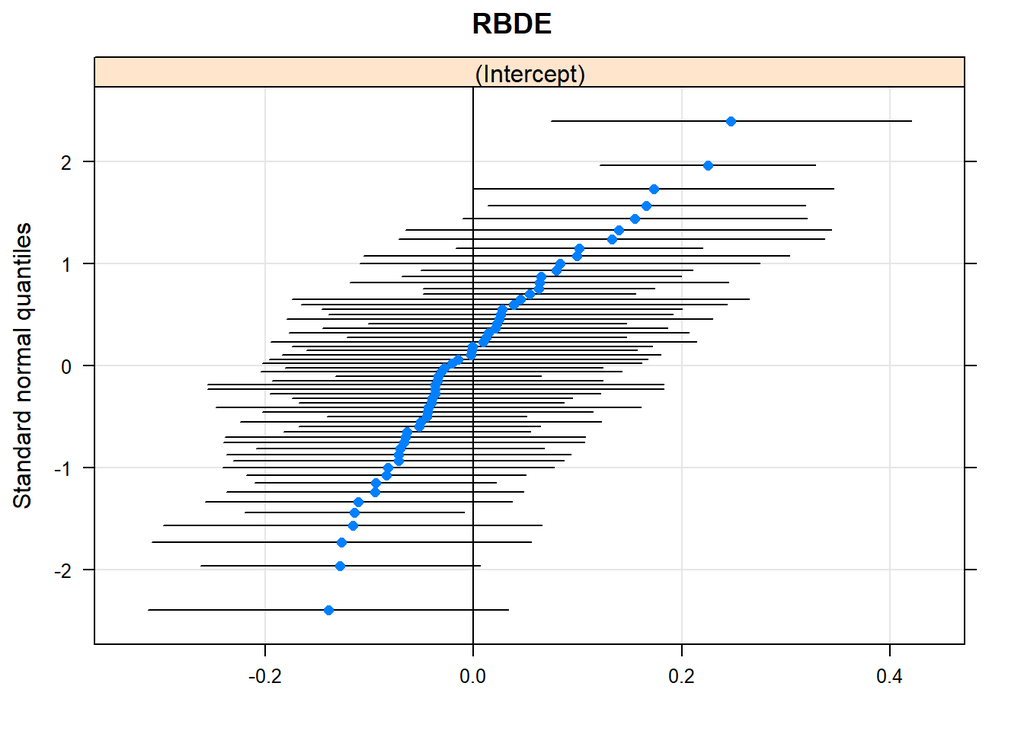

```r
qqmath(ranef(m002, condVar = TRUE))
```

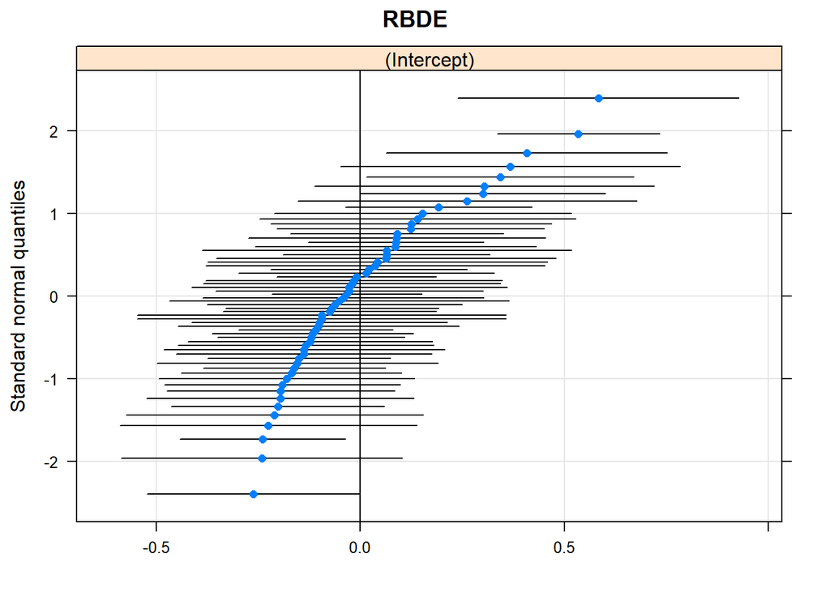

```r
qqmath(ranef(m003, condVar = TRUE))
```

# Modelos generales - Participación formal

```r
# Hipótesis 1 - Incidencia de socialización política familiar sobre participación formal
m1 <- lmer(formal ~ 1  + conversacion + voto_apod + factor(region) + factor(dependencia) + factor(sexo) + (1 |RBDE), data_red)

m1a <- lmer(formal ~ 1  + conversacion + factor(region) + factor(dependencia)+ factor(sexo) + (1 |RBDE), data_red)

m1b <- lmer(formal ~ 1   + voto_apod + factor(region) + factor(dependencia)+ factor(sexo) + (1 |RBDE), data_red)

# Hipótesis 2 - Incidencia de recursos socioeconómicos sobre participación formal
m2 <- lmer(formal ~ 1 + pad_libros + educ_apod + factor(region) + factor(dependencia) + factor(sexo) + (1 |RBDE), data_red)

m2a <- lmer(formal ~ 1 + pad_libros  + factor(region) + factor(dependencia) + factor(sexo) + (1 |RBDE), data_red)

m2b <- lmer(formal ~ 1 + educ_apod + factor(region) + factor(dependencia) + factor(sexo) + (1 |RBDE), data_red)

#m2c <- lmer(formal ~ 1 + quintil + factor(region) + factor(dependencia) + factor(sexo) + (1 |RBDE), data_red)

# Hipótesis 3 - Incidencia de socialización política escolar sobre participación formal
m3 <- lmer(formal ~ 1  +  civico_gc + meancivico + apertura_gc + meanap + factor(region) + factor(dependencia)+ factor(sexo) + (1 |RBDE), data_red)

m3a <- lmer(formal ~ 1  +  civico_gc + meancivico + factor(region) + factor(dependencia)+ factor(sexo) + (1 |RBDE), data_red)

m3b <- lmer(formal ~ 1  + apertura_gc + meanap + factor(region) + factor(dependencia)+ factor(sexo) + (1 |RBDE), data_red)

# Modelo saturado - con pendiente fija
m4 <- lmer(formal ~ 1  + conversacion + voto_apod + educ_apod + pad_libros + civico_gc + meancivico + apertura_gc + meanap + factor(region) + factor(dependencia)+ factor(sexo) + (1 |RBDE), data_red)

# Resumen
#screenreg(list(m1, m2, m3, m4), custom.model.names = c("soc. familiar", "recursos", "soc. escolar", "completo"), omit.coef = "(sexo|dependencia|region)")
#screenreg(list(m1a, m1b, m2a, m2b, m3a, m3b, m4), custom.model.names = c("conversación", "voto familiar", "libros","educación", "civico", "apertura", "completo"), omit.coef = "(sexo|dependencia|region)")
```

```r
stargazer(list(m1a, m1b, m2a, m2b, m3a, m3b, m4), type="html", title= "Tabla 1: Modelos para participación formal", style = "default", covariate.labels = c("Conversación", "Familia votó", "11 a 25 libros(vs menos de 10)", "26 a 100 libros(vs menos de 10)", "100 o más libros(vs menos de 10)", "Ed. Media (vs Básica)", "Ed. Técnica (vs Básica)", "Ed. Universitaria (vs Básica)", "Actividades cívicas(centrada)", "Actividades cívicas(promedio)", "Apertura a discusión(centrada)", "Apertura a discusión(promedio)", "Maule (vs Antofagasta)", "RM (vs Antofagasta)", "Subvencionado(vs Público)", "Privado(vs Público)", "Niña"),
          dep.var.caption  = "Indicador de Participación formal",
          dep.var.labels   = "", digits= 2,
          star.char = c("+", "*", "**", "***"),
          star.cutoffs = c(0.1, 0.05, 0.01, 0.001),
          notes = c("+ p<=0.1; * p<=0.05; ** p<=0.01; *** p<0.001"),
          notes.append = F,
          column.labels = c("Conversación", "Familia marchó", "libros","Educación", "Actividades cívicas", "Apertura a disucusión", "completo"), model.numbers          = FALSE)
```

**Tabla 1: Modelos para participación formal**

Indicador de Participación formal

Conversación

Familia marchó

libros

Educación

Actividades cívicas

Apertura a disucusión

completo

Conversación

0.21***

0.17***

(0.03)

(0.03)

Familia votó

0.21***

0.16***

(0.05)

(0.04)

11 a 25 libros(vs menos de 10)

0.06

0.01

(0.06)

(0.06)

26 a 100 libros(vs menos de 10)

0.14*

0.05

(0.06)

(0.06)

100 o más libros(vs menos de 10)

0.19**

0.08

(0.07)

(0.07)

Ed. Media (vs Básica)

0.09

0.11<sup>+</sup>

(0.07)

(0.07)

Ed. Técnica (vs Básica)

0.24**

0.22**

(0.08)

(0.07)

Ed. Universitaria (vs Básica)

0.25**

0.17*

(0.09)

(0.08)

Actividades cívicas(centrada)

0.05***

0.03**

(0.01)

(0.01)

Actividades cívicas(promedio)

0.03

0.002

(0.03)

(0.03)

Apertura a discusión(centrada)

0.09**

0.02

(0.03)

(0.03)

Apertura a discusión(promedio)

0.24**

0.07

(0.09)

(0.09)

Maule (vs Antofagasta)

0.09

0.01

0.06

0.05

0.02

0.05

0.04

(0.07)

(0.08)

(0.08)

(0.08)

(0.09)

(0.08)

(0.07)

RM (vs Antofagasta)

-0.02

-0.08

-0.05

-0.05

-0.06

-0.07

-0.08

(0.07)

(0.07)

(0.07)

(0.07)

(0.07)

(0.07)

(0.07)

Subvencionado(vs Público)

0.08

0.08

0.09

0.07

0.10

0.08

0.05

(0.06)

(0.06)

(0.06)

(0.06)

(0.06)

(0.06)

(0.05)

Privado(vs Público)

0.23**

0.24**

0.24**

0.19*

0.30***

0.26**

0.12

(0.07)

(0.08)

(0.08)

(0.09)

(0.08)

(0.08)

(0.08)

Niña

-0.03

-0.09*

-0.08<sup>+</sup>

-0.08<sup>+</sup>

-0.08<sup>+</sup>

-0.05

-0.04

(0.04)

(0.04)

(0.04)

(0.04)

(0.04)

(0.04)

(0.04)

Constant

-0.76***

-0.28***

-0.26**

-0.28**

-0.30*

-0.89**

-1.10***

(0.10)

(0.07)

(0.08)

(0.09)

(0.14)

(0.28)

(0.26)

Observations

524

524

524

524

524

524

524

Log Likelihood

-338.90

-356.60

-366.25

-362.91

-360.99

-362.17

-342.26

Akaike Inf. Crit.

695.80

731.20

754.50

747.82

741.99

744.34

724.52

Bayesian Inf. Crit.

734.15

769.55

801.37

794.70

784.60

786.96

809.75

*Note:*

- p<=0.1; * p<=0.05; ** p<=0.01; *** p<0.001

## Evaluación de interacción entre niveles: Modelos H4 y H5

```r
#Hipótesis 4 - Interacción entre variables de nivel 1 (conversacion y voto_apod) con variables de nivel 2 (apertura y actividades cívicas)

# Modelo con Socialización política indirecta liberada
m5 <- lmer(formal ~ 1  + conversacion + voto_apod  + educ_apod + pad_libros + civico_gc + meancivico + apertura_gc + meanap + factor(region) + factor(dependencia) + factor(sexo) + (1 + conversacion |RBDE), data_red)
```

```
## boundary (singular) fit: see ?isSingular
```

```r
anova(m4, m5)
```

```
## refitting model(s) with ML (instead of REML)
```

```
## Data: data_red
## Models:
## m4: formal ~ 1 + conversacion + voto_apod + educ_apod + pad_libros +
## m4:     civico_gc + meancivico + apertura_gc + meanap + factor(region) +
## m4:     factor(dependencia) + factor(sexo) + (1 | RBDE)
## m5: formal ~ 1 + conversacion + voto_apod + educ_apod + pad_libros +
## m5:     civico_gc + meancivico + apertura_gc + meanap + factor(region) +
## m5:     factor(dependencia) + factor(sexo) + (1 + conversacion |
## m5:     RBDE)
##    npar    AIC    BIC  logLik deviance  Chisq Df Pr(>Chisq)
## m4   20 643.24 728.47 -301.62   603.24
## m5   22 639.21 732.96 -297.60   595.21 8.0366  2    0.01798 *
## ---
## Signif. codes:  0 '***' 0.001 '**' 0.01 '*' 0.05 '.' 0.1 ' ' 1
```

```r
# Modelo con socialización política indirecta liberada con interacción con actividades cívicas
m5a <- lmer(formal ~ 1  + conversacion + voto_apod   + educ_apod + pad_libros + civico_gc + meancivico + apertura_gc + meanap + factor(region) + factor(dependencia) + factor(sexo) + conversacion * meanap + (1 + conversacion |RBDE), data_red)
```

```
## boundary (singular) fit: see ?isSingular
```

```r
# Modelo con socialización política indirecta liberada con interacción con apertura a la discusión
m5b <- lmer(formal ~ 1  + conversacion + voto_apod   + educ_apod + pad_libros + civico_gc + meancivico + apertura_gc + meanap + factor(region) + factor(dependencia) + factor(sexo) + conversacion * meancivico + (1 + conversacion |RBDE), data_red)
```

```
## boundary (singular) fit: see ?isSingular
```

```r
#qqmath(ranef(m5, condVar = FALSE))


#skim(data_red$conversacion)

#screenreg(list(m4, m5, m5a, m5b), custom.model.names = c("m4", "m5", "m5a", "m5b"))

rrm5 <- ranef(m5)
str(dd <- as.data.frame(rrm5))
```

```
## 'data.frame':    120 obs. of  5 variables:
##  $ grpvar : chr  "RBDE" "RBDE" "RBDE" "RBDE" ...
##  $ term   : Factor w/ 2 levels "(Intercept)",..: 1 1 1 1 1 1 1 1 1 1 ...
##  $ grp    : Factor w/ 60 levels "16415","12868",..: 57 32 29 60 22 27 31 9 26 13 ...
##  $ condval: num  0.3256 0.0134 -0.0115 0.4228 -0.08 ...
##  $ condsd : num  0.29 0.387 0.295 0.33 0.376 ...
```

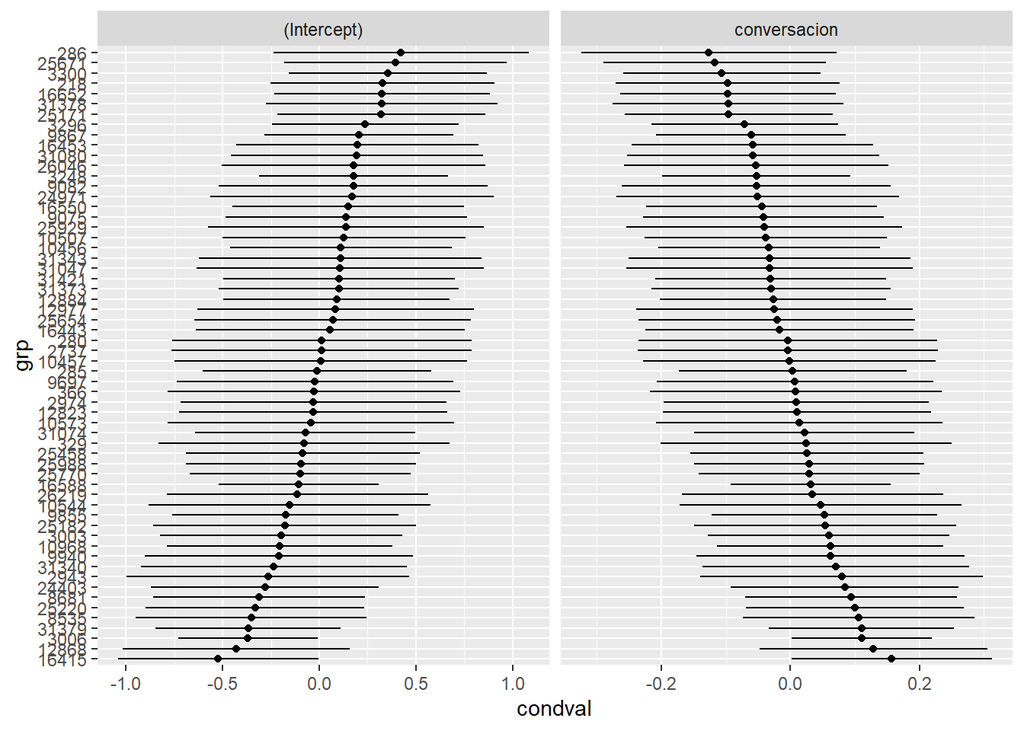

```r
if (require(ggplot2)) {
    ggplot(dd, aes(y=grp,x=condval)) +
        geom_point() + facet_wrap(~term,scales="free_x") +
        geom_errorbarh(aes(xmin=condval -2*condsd,
                           xmax=condval +2*condsd), height=0)
}
```

```r
#Hipótesis 4 - Interacción entre variables de nivel 1 (conversacion y voto_apod) con variables de nivel 2 (apertura y actividades cívicas)
# Modelo de socialización política directa liberada
m6 <- lmer(formal ~ 1  + conversacion + voto_apod   + educ_apod + pad_libros + civico_gc + meancivico + apertura_gc + meanap + factor(region) + factor(dependencia) + factor(sexo) + (1+voto_apod |RBDE), data_red)
```

```
## boundary (singular) fit: see ?isSingular
```

```r
anova(m4, m6)
```

```
## refitting model(s) with ML (instead of REML)
```

```
## Data: data_red
## Models:
## m4: formal ~ 1 + conversacion + voto_apod + educ_apod + pad_libros +
## m4:     civico_gc + meancivico + apertura_gc + meanap + factor(region) +
## m4:     factor(dependencia) + factor(sexo) + (1 | RBDE)
## m6: formal ~ 1 + conversacion + voto_apod + educ_apod + pad_libros +
## m6:     civico_gc + meancivico + apertura_gc + meanap + factor(region) +
## m6:     factor(dependencia) + factor(sexo) + (1 + voto_apod | RBDE)
##    npar    AIC    BIC  logLik deviance  Chisq Df Pr(>Chisq)
## m4   20 643.24 728.47 -301.62   603.24
## m6   22 641.64 735.39 -298.82   597.64 5.6056  2    0.06064 .
## ---
## Signif. codes:  0 '***' 0.001 '**' 0.01 '*' 0.05 '.' 0.1 ' ' 1
```

```r
m6a <- lmer(formal ~ 1  + conversacion + voto_apod + educ_apod + pad_libros + civico_gc + meancivico + apertura_gc + meanap + factor(region) + factor(dependencia) + factor(sexo) + voto_apod * meanap + (1+voto_apod  |RBDE), data_red)
```

```
## boundary (singular) fit: see ?isSingular
```

```r
m6b <- lmer(formal ~ 1  + conversacion + voto_apod + educ_apod + pad_libros + civico_gc + meancivico + apertura_gc + meanap + factor(region) + factor(dependencia) + factor(sexo) + voto_apod * meancivico + (1+voto_apod  |RBDE), data_red)
```

```
## boundary (singular) fit: see ?isSingular
```

```r
#screenreg(list(m4, m6, m6a, m6b), custom.model.names = c("m4", "m6", "m6a", "m6b"))

rrm6 <- ranef(m6)
str(dd <- as.data.frame(rrm6))
```

```
## 'data.frame':    120 obs. of  5 variables:
##  $ grpvar : chr  "RBDE" "RBDE" "RBDE" "RBDE" ...
##  $ term   : Factor w/ 2 levels "(Intercept)",..: 1 1 1 1 1 1 1 1 1 1 ...
##  $ grp    : Factor w/ 60 levels "3006","10457",..: 57 31 38 60 9 32 30 28 14 20 ...
##  $ condval: num  0.21937 0.00737 0.02644 0.25445 -0.12903 ...
##  $ condsd : num  0.161 0.216 0.173 0.176 0.174 ...
```

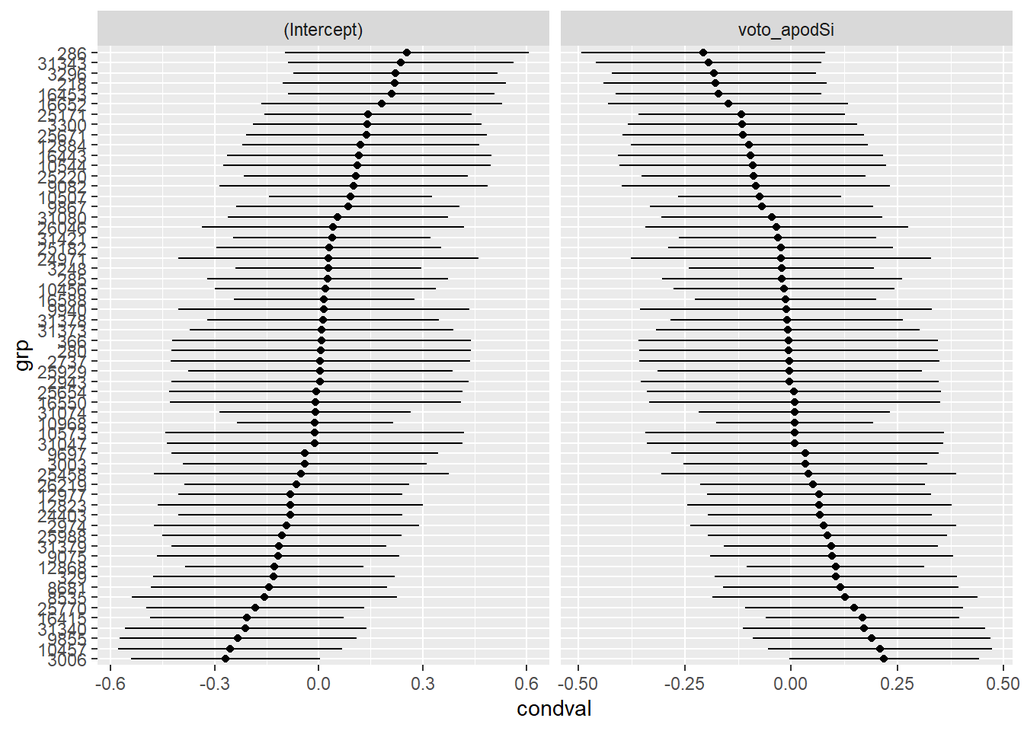

```r
if (require(ggplot2)) {
    ggplot(dd, aes(y=grp,x=condval)) +
        geom_point() + facet_wrap(~term,scales="free_x") +
        geom_errorbarh(aes(xmin=condval -2*condsd,
                           xmax=condval +2*condsd), height=0)
}
```

Evaluación de pendiente aleatoria de “Educación de los padres”: según el resultado del *loglikelihood ratio test* la pendiente entre educación e intención de participación formal NO es aleatoria a trávez de las escuelas (p=0,659). Considerando este resultado, no se evalúa la interacción entre niveles

```r
#Hipótesis 5 - Interacción entre variables de nivel 1 (educación y libros) con variables de nivel 2 (apertura y actividades cívicas)

# Modelo con Socialización política indirecta liberada
m7 <- lmer(formal ~ 1  + conversacion + voto_apod  + educ_apod + pad_libros + civico_gc + meancivico + apertura_gc + meanap + factor(region) + factor(dependencia) + factor(sexo) + (1 + educ_apod |RBDE), data_red)
```

```
## boundary (singular) fit: see ?isSingular
```

```r
anova(m4, m7)
```

```
## refitting model(s) with ML (instead of REML)
```

```
## Data: data_red
## Models:
## m4: formal ~ 1 + conversacion + voto_apod + educ_apod + pad_libros +
## m4:     civico_gc + meancivico + apertura_gc + meanap + factor(region) +
## m4:     factor(dependencia) + factor(sexo) + (1 | RBDE)
## m7: formal ~ 1 + conversacion + voto_apod + educ_apod + pad_libros +
## m7:     civico_gc + meancivico + apertura_gc + meanap + factor(region) +
## m7:     factor(dependencia) + factor(sexo) + (1 + educ_apod | RBDE)
##    npar    AIC    BIC  logLik deviance  Chisq Df Pr(>Chisq)
## m4   20 643.24 728.47 -301.62   603.24
## m7   29 654.46 778.04 -298.23   596.46 6.7831  9     0.6597
```

```r
# Modelo con socialización política indirecta liberada con interacción con actividades cívicas
#m7a <- lmer(formal ~ 1  + conversacion + voto_apod   + educ_apod + pad_libros + civico_gc + meancivico + apertura_gc + meanap + factor(region) + factor(dependencia) + factor(sexo) + conversacion * meanap + (1 + educ_apod |RBDE), data_red)

# Modelo con socialización política indirecta liberada con interacción con apertura a la discusión
#m7b <- lmer(formal ~ 1  + conversacion + voto_apod   + educ_apod + pad_libros + civico_gc + meancivico + apertura_gc + meanap + factor(region) + factor(dependencia) + factor(sexo) + conversacion * meancivico + (1 + educ_apod |RBDE), data_red)

#skim(data_red$conversacion)

#screenreg(list(m4, m7), custom.model.names = c("m4", "m7"))
```

```r
#Hipótesis 5 - Interacción entre variables de nivel 1 (educación y libros) con variables de nivel 2 (apertura y actividades cívicas)

# Modelo con Socialización política indirecta liberada
m8 <- lmer(formal ~ 1  + conversacion + voto_apod  + educ_apod + pad_libros + civico_gc + meancivico + apertura_gc + meanap + factor(region) + factor(dependencia) + factor(sexo) + (1 + pad_libros |RBDE), data_red)
```

```
## boundary (singular) fit: see ?isSingular
```

```r
anova(m4, m8)
```

```
## refitting model(s) with ML (instead of REML)
```

```
## Data: data_red
## Models:
## m4: formal ~ 1 + conversacion + voto_apod + educ_apod + pad_libros +
## m4:     civico_gc + meancivico + apertura_gc + meanap + factor(region) +
## m4:     factor(dependencia) + factor(sexo) + (1 | RBDE)
## m8: formal ~ 1 + conversacion + voto_apod + educ_apod + pad_libros +
## m8:     civico_gc + meancivico + apertura_gc + meanap + factor(region) +
## m8:     factor(dependencia) + factor(sexo) + (1 + pad_libros | RBDE)
##    npar    AIC    BIC  logLik deviance  Chisq Df Pr(>Chisq)
## m4   20 643.24 728.47 -301.62   603.24
## m8   29 659.52 783.10 -300.76   601.52 1.7248  9     0.9951
```

```r
# Modelo con socialización política indirecta liberada con interacción con actividades cívicas
#m7a <- lmer(formal ~ 1  + conversacion + voto_apod   + educ_apod + pad_libros + civico_gc + meancivico + apertura_gc + meanap + factor(region) + factor(dependencia) + factor(sexo) + conversacion * meanap + (1 + educ_apod |RBDE), data_red)

# Modelo con socialización política indirecta liberada con interacción con apertura a la discusión
#m7b <- lmer(formal ~ 1  + conversacion + voto_apod   + educ_apod + pad_libros + civico_gc + meancivico + apertura_gc + meanap + factor(region) + factor(dependencia) + factor(sexo) + conversacion * meancivico + (1 + educ_apod |RBDE), data_red)

#skim(data_red$conversacion)

#screenreg(list(m4, m7), custom.model.names = c("m4", "m8"))
```

# Modelos generales - Participación disruptiva

```r
d1 <- lmer(disruptivo ~ 1  + conversacion + factor(act_marcha) + factor(region) + factor(dependencia)+ factor(sexo) + (1 |RBDE), data_red)

d1a <- lmer(disruptivo ~ 1  + conversacion + factor(region) + factor(dependencia)+ factor(sexo) + (1 |RBDE), data_red)

d1b <- lmer(disruptivo ~ 1  + factor(act_marcha) + factor(region) + factor(dependencia)+ factor(sexo) + (1 |RBDE), data_red)

d2 <- lmer(disruptivo ~ 1   + pad_libros + educ_apod + factor(region) + factor(dependencia) + factor(sexo) + (1 |RBDE), data_red)

d2a <- lmer(disruptivo ~ 1   +  pad_libros + factor(region) + factor(dependencia) + factor(sexo) + (1 |RBDE), data_red)

d2b <- lmer(disruptivo ~ 1   + educ_apod + factor(region) + factor(dependencia) + factor(sexo) + (1 |RBDE), data_red)

d3 <- lmer(disruptivo ~ 1  +  civico_gc + meancivico + apertura_gc + meanap + factor(region) + factor(dependencia)+ factor(sexo) + (1 |RBDE), data_red)

d3a <- lmer(disruptivo ~ 1  +   civico_gc + meancivico + factor(region) + factor(dependencia)+ factor(sexo) + (1 |RBDE), data_red)

d3b <- lmer(disruptivo ~ 1  +  apertura_gc + meanap +  factor(region) + factor(dependencia)+ factor(sexo) + (1 |RBDE), data_red)

d4 <- lmer(disruptivo ~ 1  + conversacion + factor(act_marcha) + pad_libros + educ_apod + civico_gc + meancivico + apertura_gc + meanap + factor(region) + factor(dependencia)+ factor(sexo) + (1 |RBDE), data_red)

#Tabla de regresiones
#screenreg(list(d1, d2, d3, d4), custom.model.names = c("soc. familiar", "recursos", "soc. escolar", "completo"), omit.coef = "(sexo|dependencia|region)")

#screenreg(list(d1a, d1b, d2a, d2b, d3a, d3b, d4), custom.model.names = c("conversación", "marcha familia", "libros","educación", "cívico", "apertura", "completo"), omit.coef = "(sexo|dependencia|region)")
```

## Tabla resumen: H1, H2, H3

```r
stargazer(list(d1a, d1b, d2a, d2b, d3a, d3b, d4), type="html", title= "Tabla 2: Modelos para participación disruptiva", style = "default", covariate.labels = c("Conversación", "Familia marchó", "11 a 25 libros(vs menos de 10)", "26 a 100 libros(vs menos de 10)", "100 o más libros(vs menos de 10)", "Ed. Media (vs Básica)", "Ed. Técnica (vs Básica)", "Ed. Universitaria (vs Básica)", "Actividades cívicas(centrada)", "Actividades cívicas(promedio)", "Apertura a discusión(centrada)", "Apertura a discusión(promedio)", "Maule (vs Antofagasta)", "RM (vs Antofagasta)", "Subvencionado(vs Público)", "Privado(vs Público)", "Niña"),
          dep.var.caption  = "Indicador de Participación disruptiva",
          dep.var.labels   = "", digits= 2,
          star.char = c("+", "*", "**", "***"),
          star.cutoffs = c(0.1, 0.05, 0.01, 0.001),
          notes = c("+ p<=0.1; * p<=0.05; ** p<=0.01; *** p<0.001"),
          notes.append = F,
          column.labels = c("Conversación", "Familia marchó", "libros","Educación", "Actividades cívicas", "Apertura a disucusión", "completo"), model.numbers          = FALSE)
```

**Tabla 2: Modelos para participación disruptiva**

Indicador de Participación disruptiva

Conversación

Familia marchó

libros

Educación

Actividades cívicas

Apertura a disucusión

completo

Conversación

0.08*

0.07*

(0.03)

(0.03)

Familia marchó

0.16*

0.16*

(0.07)

(0.07)

11 a 25 libros(vs menos de 10)

0.05

0.03

(0.08)

(0.08)

26 a 100 libros(vs menos de 10)

0.07

0.05

(0.07)

(0.07)

100 o más libros(vs menos de 10)

0.10

0.09

(0.09)

(0.09)

Ed. Media (vs Básica)

0.08

0.06

(0.09)

(0.09)

Ed. Técnica (vs Básica)

0.08

0.06

(0.10)

(0.10)

Ed. Universitaria (vs Básica)

0.04

-0.03

(0.11)

(0.11)

Actividades cívicas(centrada)

0.03*

0.03<sup>+</sup>

(0.01)

(0.01)

Actividades cívicas(promedio)

0.01

0.03

(0.05)

(0.05)

Apertura a discusión(centrada)

0.04

0.02

(0.04)

(0.04)

Apertura a discusión(promedio)

-0.16

-0.23

(0.16)

(0.16)

Maule (vs Antofagasta)

0.09

0.07

0.07

0.07

0.06

0.08

0.08

(0.13)

(0.13)

(0.14)

(0.14)

(0.14)

(0.14)

(0.14)

RM (vs Antofagasta)

0.12

0.10

0.10

0.10

0.10

0.13

0.13

(0.12)

(0.11)

(0.12)

(0.12)

(0.12)

(0.12)

(0.12)

Subvencionado(vs Público)

-0.08

-0.07

-0.07

-0.07

-0.07

-0.05

-0.06

(0.10)

(0.10)

(0.10)

(0.10)

(0.10)

(0.10)

(0.10)

Privado(vs Público)

-0.21

-0.17

-0.21

-0.18

-0.18

-0.14

-0.14

(0.13)

(0.13)

(0.14)

(0.14)

(0.13)

(0.14)

(0.15)

Niña

-0.08

-0.11*

-0.10<sup>+</sup>

-0.11<sup>+</sup>

-0.10<sup>+</sup>

-0.10<sup>+</sup>

-0.09<sup>+</sup>

(0.05)

(0.05)

(0.05)

(0.05)

(0.05)

(0.05)

(0.05)

Constant

-0.06

0.15

0.13

0.12

0.14

0.63

0.42

(0.15)

(0.11)

(0.13)

(0.13)

(0.21)

(0.47)

(0.48)

Observations

524

524

524

524

524

524

524

Log Likelihood

-456.89

-456.57

-462.16

-462.08

-460.19

-459.59

-470.59

Akaike Inf. Crit.

931.77

931.14

946.32

946.15

940.38

939.17

981.19

Bayesian Inf. Crit.

970.12

969.50

993.20

993.03

983.00

981.79

1,066.42

*Note:*

- p<=0.1; * p<=0.05; ** p<=0.01; *** p<0.001

## Evaluación de interacción entre niveles: Modelos H4 y H5

Evaluación de pendiente aleatoria de “Conversación familiar”: según el resultado del *loglikelihood ratio test* la pendiente entre convseración e intención de participación disruptiva NO es aleatoria a trávez de las escuelas (p=0,469). Considerando este resultado, no se evalúa la interacción entre niveles.

```r
#Hipótesis 4 - Interacción entre variables de nivel 1 (conversacion y voto_apod) con variables de nivel 2 (apertura y actividades cívicas)

# Modelo con Socialización política indirecta liberada
d5 <- lmer(disruptivo ~ 1  + conversacion + factor(act_marcha) + educ_apod + pad_libros + civico_gc + meancivico + apertura_gc + meanap + factor(region) + factor(dependencia) + factor(sexo) + (1 + conversacion |RBDE), data_red)

anova(d4, d5)
```

```
## refitting model(s) with ML (instead of REML)
```

```
## Data: data_red
## Models:
## d4: disruptivo ~ 1 + conversacion + factor(act_marcha) + pad_libros +
## d4:     educ_apod + civico_gc + meancivico + apertura_gc + meanap +
## d4:     factor(region) + factor(dependencia) + factor(sexo) + (1 |
## d4:     RBDE)
## d5: disruptivo ~ 1 + conversacion + factor(act_marcha) + educ_apod +
## d5:     pad_libros + civico_gc + meancivico + apertura_gc + meanap +
## d5:     factor(region) + factor(dependencia) + factor(sexo) + (1 +
## d5:     conversacion | RBDE)
##    npar    AIC    BIC  logLik deviance  Chisq Df Pr(>Chisq)
## d4   20 915.02 1000.2 -437.51   875.02
## d5   22 917.51 1011.3 -436.76   873.51 1.5119  2     0.4696
```

```r
# Modelo con socialización política indirecta liberada con interacción con actividades cívicas
#d5a <- lmer(disruptivo ~ 1  + conversacion + act_marcha   + educ_apod + pad_libros + civico_gc + meancivico + apertura_gc + meanap + factor(region) + factor(dependencia) + factor(sexo) + conversacion * meanap + (1 + conversacion |RBDE), data_red)

# Modelo con socialización política indirecta liberada con interacción con apertura a la discusión
#d5b <- lmer(disruptivo ~ 1  + conversacion + act_marcha   + educ_apod + pad_libros + civico_gc + meancivico + apertura_gc + meanap + factor(region) + factor(dependencia) + factor(sexo) + conversacion * meancivico + (1 + conversacion |RBDE), data_red)

#skim(data_red$conversacion)

#screenreg(list(d4, d5), custom.model.names = c("d4", "d5"))
```

Evaluación de pendiente aleatoria de “haber marchado”: según el resultado del *loglikelihood ratio test* la pendiente entre haber marchado e intención de participación disruptiva es *marginalmente* aleatoria a trávez de las escuelas (p= 0,072). A pesar del efecto marginal, se evaluó la interacción entre niveles.

```r
#Hipótesis 4 - Interacción entre variables de nivel 1 (conversacion y voto_apod) con variables de nivel 2 (apertura y actividades cívicas)
# Modelo de socialización política directa liberada
d6 <- lmer(disruptivo ~ 1  + conversacion + factor(act_marcha)   + educ_apod + pad_libros + civico_gc + meancivico + apertura_gc + meanap + factor(region) + factor(dependencia) + factor(sexo) + (1+factor(act_marcha) |RBDE), data_red)

anova(d4, d6)
```

```
## refitting model(s) with ML (instead of REML)
```

```
## Data: data_red
## Models:
## d4: disruptivo ~ 1 + conversacion + factor(act_marcha) + pad_libros +
## d4:     educ_apod + civico_gc + meancivico + apertura_gc + meanap +
## d4:     factor(region) + factor(dependencia) + factor(sexo) + (1 |
## d4:     RBDE)
## d6: disruptivo ~ 1 + conversacion + factor(act_marcha) + educ_apod +
## d6:     pad_libros + civico_gc + meancivico + apertura_gc + meanap +
## d6:     factor(region) + factor(dependencia) + factor(sexo) + (1 +
## d6:     factor(act_marcha) | RBDE)
##    npar    AIC    BIC  logLik deviance Chisq Df Pr(>Chisq)
## d4   20 915.02 1000.2 -437.51   875.02
## d6   22 913.76 1007.5 -434.88   869.76 5.259  2    0.07211 .
## ---
## Signif. codes:  0 '***' 0.001 '**' 0.01 '*' 0.05 '.' 0.1 ' ' 1
```

```r
d6a <- lmer(disruptivo ~ 1  + conversacion + factor(act_marcha) + educ_apod + pad_libros + civico_gc + meancivico + apertura_gc + meanap + factor(region) + factor(dependencia) + factor(sexo) + factor(act_marcha) * meanap + (1+ factor(act_marcha) |RBDE), data_red)

d6b <- lmer(disruptivo ~ 1  + conversacion + factor(act_marcha) + educ_apod + pad_libros + civico_gc + meancivico + apertura_gc + meanap + factor(region) + factor(dependencia) + factor(sexo) + factor(act_marcha) * meancivico + (1+ factor(act_marcha) |RBDE), data_red)

#screenreg(list(d4, d6, d6a, d6b), custom.model.names = c("d4", "d6", "d6a", "d6b"))

#install.packages("sjPlot")
#install.packages("insight")
#install.packages(c("effectsize", "ggeffects", "parameters", "bayestestR", "sjlabelled", "insight", "sjPlot"))
#library(insight)
#library(sjPlot)

#dotplot(ranef(d6, condVar = TRUE))



rrd6 <- ranef(d6)
str(dd <- as.data.frame(rrd6))
```

```
## 'data.frame':    120 obs. of  5 variables:
##  $ grpvar : chr  "RBDE" "RBDE" "RBDE" "RBDE" ...
##  $ term   : Factor w/ 2 levels "(Intercept)",..: 1 1 1 1 1 1 1 1 1 1 ...
##  $ grp    : Factor w/ 60 levels "10457","26219",..: 25 52 11 58 12 48 20 46 50 31 ...
##  $ condval: num  -0.0806 0.1916 -0.1762 0.4184 -0.1736 ...
##  $ condsd : num  0.178 0.245 0.219 0.223 0.18 ...
```

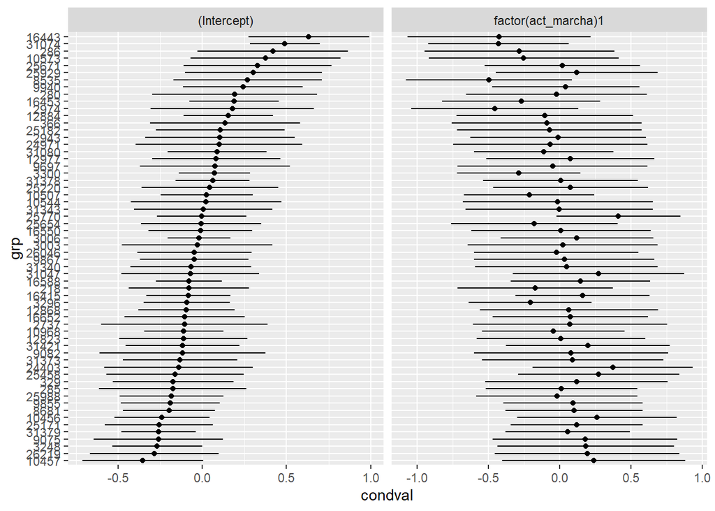

```r
if (require(ggplot2)) {
    ggplot(dd, aes(y=grp,x=condval)) +
        geom_point() + facet_wrap(~term,scales="free_x") +
        geom_errorbarh(aes(xmin=condval -2*condsd,
                           xmax=condval +2*condsd), height=0)
}
```

Evaluación de pendiente aleatoria de “Educación de los padres”: según el resultado del *loglikelihood ratio test* la pendiente entre educación e intención de participación disruptiva NO es aleatoria a trávez de las escuelas (p=0,913). Considerando este resultado, no se evalúa la interacción entre niveles.

```r
#Hipótesis 5 - Interacción entre variables de nivel 1 (educación y libros) con variables de nivel 2 (apertura y actividades cívicas)

# Modelo con Socialización política indirecta liberada
d7 <- lmer(disruptivo ~ 1  + conversacion + voto_apod  + educ_apod + pad_libros + civico_gc + meancivico + apertura_gc + meanap + factor(region) + factor(dependencia) + factor(sexo) + (1 + educ_apod |RBDE), data_red)
anova(d4, d7)
```

```
## refitting model(s) with ML (instead of REML)
```

```
## Data: data_red
## Models:
## d4: disruptivo ~ 1 + conversacion + factor(act_marcha) + pad_libros +
## d4:     educ_apod + civico_gc + meancivico + apertura_gc + meanap +
## d4:     factor(region) + factor(dependencia) + factor(sexo) + (1 |
## d4:     RBDE)
## d7: disruptivo ~ 1 + conversacion + voto_apod + educ_apod + pad_libros +
## d7:     civico_gc + meancivico + apertura_gc + meanap + factor(region) +
## d7:     factor(dependencia) + factor(sexo) + (1 + educ_apod | RBDE)
##    npar    AIC    BIC  logLik deviance  Chisq Df Pr(>Chisq)
## d4   20 915.02 1000.2 -437.51   875.02
## d7   29 929.04 1052.6 -435.52   871.04 3.9799  9     0.9127
```

```r
# Modelo con socialización política indirecta liberada con interacción con actividades cívicas
#m7a <- lmer(formal ~ 1  + conversacion + voto_apod   + educ_apod + pad_libros + civico_gc + meancivico + apertura_gc + meanap + factor(region) + factor(dependencia) + factor(sexo) + conversacion * meanap + (1 + educ_apod |RBDE), data_red)

# Modelo con socialización política indirecta liberada con interacción con apertura a la discusión
#m7b <- lmer(formal ~ 1  + conversacion + voto_apod   + educ_apod + pad_libros + civico_gc + meancivico + apertura_gc + meanap + factor(region) + factor(dependencia) + factor(sexo) + conversacion * meancivico + (1 + educ_apod |RBDE), data_red)

#skim(data_red$conversacion)

#screenreg(list(m4, m7), custom.model.names = c("m4", "m7"))
```

Evaluación de pendiente aleatoria de “Libros en el hogar”: según el resultado del *loglikelihood ratio test* la pendiente entre libros e intención de participación disruptiva NO es aleatoria a trávez de las escuelas (p=1,000). Considerando este resultado, no se evalúa la interacción entre niveles

```r
#Hipótesis 5 - Interacción entre variables de nivel 1 (educación y libros) con variables de nivel 2 (apertura y actividades cívicas)

# Modelo con Socialización política indirecta liberada
d8 <- lmer(disruptivo ~ 1  + conversacion + voto_apod  + educ_apod + pad_libros + civico_gc + meancivico + apertura_gc + meanap + factor(region) + factor(dependencia) + factor(sexo) + (1 + pad_libros |RBDE), data_red)
```

```
## boundary (singular) fit: see ?isSingular
```

```r
anova(d4, d8)
```

```
## refitting model(s) with ML (instead of REML)
```

```
## Data: data_red
## Models:
## d4: disruptivo ~ 1 + conversacion + factor(act_marcha) + pad_libros +
## d4:     educ_apod + civico_gc + meancivico + apertura_gc + meanap +
## d4:     factor(region) + factor(dependencia) + factor(sexo) + (1 |
## d4:     RBDE)
## d8: disruptivo ~ 1 + conversacion + voto_apod + educ_apod + pad_libros +
## d8:     civico_gc + meancivico + apertura_gc + meanap + factor(region) +
## d8:     factor(dependencia) + factor(sexo) + (1 + pad_libros | RBDE)
##    npar    AIC    BIC  logLik deviance Chisq Df Pr(>Chisq)
## d4   20 915.02 1000.2 -437.51   875.02
## d8   29 934.18 1057.8 -438.09   876.18     0  9          1
```

```r
# Modelo con socialización política indirecta liberada con interacción con actividades cívicas
#m7a <- lmer(formal ~ 1  + conversacion + voto_apod   + educ_apod + pad_libros + civico_gc + meancivico + apertura_gc + meanap + factor(region) + factor(dependencia) + factor(sexo) + conversacion * meanap + (1 + educ_apod |RBDE), data_red)

# Modelo con socialización política indirecta liberada con interacción con apertura a la discusión
#m7b <- lmer(formal ~ 1  + conversacion + voto_apod   + educ_apod + pad_libros + civico_gc + meancivico + apertura_gc + meanap + factor(region) + factor(dependencia) + factor(sexo) + conversacion * meancivico + (1 + educ_apod |RBDE), data_red)

#skim(data_red$conversacion)

#screenreg(list(m4, m7), custom.model.names = c("m4", "m8"))
```

# Tabla con interacciones significativas

```r
stargazer(list(d1a, d1b, d2a, d2b, d3a, d3b, d4, d6a), type="html", title= "Tabla 2: Modelos para participación disruptiva", style = "default", covariate.labels = c("Conversación", "Familia marchó", "11 a 25 libros(vs menos de 10)", "26 a 100 libros(vs menos de 10)", "100 o más libros(vs menos de 10)", "Ed. Media (vs Básica)", "Ed. Técnica (vs Básica)", "Ed. Universitaria (vs Básica)", "Actividades cívicas(centrada)", "Actividades cívicas(promedio)", "Apertura a discusión(centrada)", "Apertura a discusión(promedio)", "Maule (vs Antofagasta)", "RM (vs Antofagasta)", "Subvencionado(vs Público)", "Privado(vs Público)", "Niña", "Familia marchó x apertura(mean)"),
          dep.var.caption  = "Indicador de Participación disruptiva",
          dep.var.labels   = "", digits= 2,
          star.char = c("+", "*", "**", "***"),
          star.cutoffs = c(0.1, 0.05, 0.01, 0.001),
          notes = c("+ p<=0.1; * p<=0.05; ** p<=0.01; *** p<0.001"),
          notes.append = F,
          column.labels = c("Conversación", "Familia marchó", "libros","Educación", "Actividades cívicas", "Apertura a disucusión", "completo", "Crosslevel int"), model.numbers          = FALSE)
```

**Tabla 2: Modelos para participación disruptiva**

Indicador de Participación disruptiva

Conversación

Familia marchó

libros

Educación

Actividades cívicas

Apertura a disucusión

completo

Crosslevel int

Conversación

0.08*

0.07*

0.08*

(0.03)

(0.03)

(0.03)

Familia marchó

0.16*

0.16*

-1.97*

(0.07)

(0.07)

(0.88)

11 a 25 libros(vs menos de 10)

0.05

0.03

0.03

(0.08)

(0.08)

(0.08)

26 a 100 libros(vs menos de 10)

0.07

0.05

0.05

(0.07)

(0.07)

(0.07)

100 o más libros(vs menos de 10)

0.10

0.09

0.09

(0.09)

(0.09)

(0.09)

Ed. Media (vs Básica)

0.08

0.06

0.04

(0.09)

(0.09)

(0.09)

Ed. Técnica (vs Básica)

0.08

0.06

0.06

(0.10)

(0.10)

(0.10)

Ed. Universitaria (vs Básica)

0.04

-0.03

-0.03

(0.11)

(0.11)

(0.11)

Actividades cívicas(centrada)

0.03*

0.03<sup>+</sup>

0.03*

(0.01)

(0.01)

(0.01)

Actividades cívicas(promedio)

0.01

0.03

0.01

(0.05)

(0.05)

(0.05)

Apertura a discusión(centrada)

0.04

0.02

0.01

(0.04)

(0.04)

(0.04)

Apertura a discusión(promedio)

-0.16

-0.23

-0.33<sup>+</sup>

(0.16)

(0.16)

(0.17)

Maule (vs Antofagasta)

0.09

0.07

0.07

0.07

0.06

0.08

0.08

0.08

(0.13)

(0.13)

(0.14)

(0.14)

(0.14)

(0.14)

(0.14)

(0.13)

RM (vs Antofagasta)

0.12

0.10

0.10

0.10

0.10

0.13

0.13

0.13

(0.12)

(0.11)

(0.12)

(0.12)

(0.12)

(0.12)

(0.12)

(0.11)

Subvencionado(vs Público)

-0.08

-0.07

-0.07

-0.07

-0.07

-0.05

-0.06

-0.08

(0.10)

(0.10)

(0.10)

(0.10)

(0.10)

(0.10)

(0.10)

(0.09)

Privado(vs Público)

-0.21

-0.17

-0.21

-0.18

-0.18

-0.14

-0.14

-0.20

(0.13)

(0.13)

(0.14)

(0.14)

(0.13)

(0.14)

(0.15)

(0.14)

Niña

-0.08

-0.11*

-0.10<sup>+</sup>

-0.11<sup>+</sup>

-0.10<sup>+</sup>

-0.10<sup>+</sup>

-0.09<sup>+</sup>

-0.09<sup>+</sup>

(0.05)

(0.05)

(0.05)

(0.05)

(0.05)

(0.05)

(0.05)

(0.05)

Familia marchó x apertura(mean)

0.69*

(0.28)

Constant

-0.06

0.15

0.13

0.12

0.14

0.63

0.42

0.81

(0.15)

(0.11)

(0.13)

(0.13)

(0.21)

(0.47)

(0.48)

(0.51)

Observations

524

524

524

524

524

524

524

524

Log Likelihood

-456.89

-456.57

-462.16

-462.08

-460.19

-459.59

-470.59

-465.79

Akaike Inf. Crit.

931.77

931.14

946.32

946.15

940.38

939.17

981.19

977.58

Bayesian Inf. Crit.

970.12

969.50

993.20

993.03

983.00

981.79

1,066.42

1,075.59

*Note:*

- p<=0.1; * p<=0.05; ** p<=0.01; *** p<0.001

# Modelos generales - Participación no disruptiva

```r
n1 <- lmer(nodisruptivo ~ 1  + conversacion + factor(act_marcha) + factor(region) + factor(dependencia)+ factor(sexo) + (1 |RBDE), data_red)

n1b <- lmer(nodisruptivo ~ 1  +  factor(act_marcha) + factor(region) + factor(dependencia)+ factor(sexo) + (1 |RBDE), data_red)

n1a <- lmer(nodisruptivo ~ 1  + conversacion  + factor(region) + factor(dependencia)+ factor(sexo) + (1 |RBDE), data_red)

n2 <- lmer(nodisruptivo ~ 1   + pad_libros + educ_apod + factor(region) + factor(dependencia) + factor(sexo) + (1 |RBDE), data_red)

n2b <- lmer(nodisruptivo ~ 1   + educ_apod + factor(region) + factor(dependencia) + factor(sexo) + (1 |RBDE), data_red)

n2a <- lmer(nodisruptivo ~ 1   + pad_libros + factor(region) + factor(dependencia) + factor(sexo) + (1 |RBDE), data_red)

n3 <- lmer(nodisruptivo ~ 1  +  civico_gc + meancivico + apertura_gc + meanap + factor(region) + factor(dependencia)+ factor(sexo) + (1 |RBDE), data_red)

n3b <- lmer(nodisruptivo ~ 1  +  apertura_gc + meanap + factor(region) + factor(dependencia)+ factor(sexo) + (1 |RBDE), data_red)

n3a <- lmer(nodisruptivo ~ 1  +  civico_gc + meancivico + factor(region) + factor(dependencia)+ factor(sexo) + (1 |RBDE), data_red)

n4 <- lmer(nodisruptivo ~ 1  + conversacion + factor(act_marcha) + pad_libros + educ_apod  + civico_gc + meancivico + apertura_gc + meanap + factor(region) + factor(dependencia)+ factor(sexo) + (1 |RBDE), data_red)



#screenreg(list(n1, n2, n3, n4), custom.model.names = c("soc. familiar", "recursos", "soc. escolar", "completo"), omit.coef = "(sexo|dependencia|region)")
#screenreg(list(n1a, n1b, n2a, n2b, n3a, n3b, n4), custom.model.names = c("conversación", "marcha familia", "libros","educación", "cívico(centered & mean)", "apertura(centered & mean)", "completo"), omit.coef = "(sexo|dependencia|region)", title="Multilevel models for Non-disruptive participation")
```

# Tabla resumen: H1, H2, H3

```r
stargazer(list(n1a, n1b, n2a, n2b, n3a, n3b, n4), type="html", title= "Tabla 3: Modelos para participación no-disruptiva", style = "default", covariate.labels = c("Conversación", "Familia marchó", "11 a 25 libros(vs menos de 10)", "26 a 100 libros(vs menos de 10)", "100 o más libros(vs menos de 10)", "Ed. Media (vs Básica)", "Ed. Técnica (vs Básica)", "Ed. Universitaria (vs Básica)", "Actividades cívicas(centrada)", "Actividades cívicas(promedio)", "Apertura a discusión(centrada)", "Apertura a discusión(promedio)", "Maule (vs Antofagasta)", "RM (vs Antofagasta)", "Subvencionado(vs Público)", "Privado(vs Público)", "Niña"),
          dep.var.caption  = "Indicador de Participación no-disruptiva",
          dep.var.labels   = "", digits= 2,
          star.char = c("+", "*", "**", "***"),
          star.cutoffs = c(0.1, 0.05, 0.01, 0.001),
          notes = c("+ p<=0.1; * p<=0.05; ** p<=0.01; *** p<0.001"),
          notes.append = F,
          column.labels = c("Conversación", "Familia marchó", "libros","Educación", "Actividades cívicas", "Apertura a disucusión", "completo"), model.numbers          = FALSE)
```

**Tabla 3: Modelos para participación no-disruptiva**

Indicador de Participación no-disruptiva

Conversación

Familia marchó

libros

Educación

Actividades cívicas

Apertura a disucusión

completo

Conversación

0.08***

0.07***

(0.02)

(0.02)

Familia marchó

0.09**

0.09*

(0.04)

(0.04)

11 a 25 libros(vs menos de 10)

0.03

0.02

(0.04)

(0.04)

26 a 100 libros(vs menos de 10)

0.05

0.04

(0.04)

(0.04)

100 o más libros(vs menos de 10)

0.09<sup>+</sup>

0.07

(0.05)

(0.05)

Ed. Media (vs Básica)

0.05

0.04

(0.05)

(0.04)

Ed. Técnica (vs Básica)

0.08

0.07

(0.05)

(0.05)

Ed. Universitaria (vs Básica)

0.06

0.01

(0.06)

(0.06)

Actividades cívicas(centrada)

0.03***

0.02**

(0.01)

(0.01)

Actividades cívicas(promedio)

0.01

0.02

(0.02)

(0.03)

Apertura a discusión(centrada)

0.04<sup>+</sup>

0.01

(0.02)

(0.02)

Apertura a discusión(promedio)

-0.03

-0.09

(0.08)

(0.08)

Maule (vs Antofagasta)

0.06

0.05

0.05

0.04

0.03

0.05

0.05

(0.07)

(0.07)

(0.07)

(0.07)

(0.07)

(0.07)

(0.07)

RM (vs Antofagasta)

0.05

0.03

0.04

0.03

0.03

0.04

0.04

(0.06)

(0.06)

(0.06)

(0.06)

(0.06)

(0.06)

(0.06)

Subvencionado(vs Público)

-0.02

-0.02

-0.02

-0.02

-0.01

-0.01

-0.02

(0.05)

(0.05)

(0.05)

(0.05)

(0.05)

(0.05)

(0.05)

Privado(vs Público)

-0.05

-0.01

-0.04

-0.04

-0.02

-0.01

-0.03

(0.07)

(0.07)

(0.07)

(0.07)

(0.07)

(0.07)

(0.07)

Niña

-0.04

-0.06*

-0.06*

-0.06*

-0.06*

-0.06<sup>+</sup>

-0.05<sup>+</sup>

(0.03)

(0.03)

(0.03)

(0.03)

(0.03)

(0.03)

(0.03)

Constant

-0.16*

0.04

0.02

0.01

0.01

0.14

0.004

(0.07)

(0.06)

(0.06)

(0.07)

(0.11)

(0.24)

(0.24)

Observations

524

524

524

524

524

524

524

Log Likelihood

-119.33

-124.72

-131.08

-131.47

-126.40

-128.73

-136.57

Akaike Inf. Crit.

256.65

267.44

284.17

284.95

272.80

277.46

313.14

Bayesian Inf. Crit.

295.01

305.79

331.04

331.83

315.42

320.08

398.37

*Note:*

- p<=0.1; * p<=0.05; ** p<=0.01; *** p<0.001

## Evaluación de interacción entre niveles: Modelos H4 y H5

Evaluación de pendiente aleatoria de “Conversación familiar”: según el resultado del *loglikelihood ratio test* la pendiente entre convseración e intención de participación no-disruptiva NO es aleatoria a trávez de las escuelas (p=0,747). Considerando este resultado, no se evalúa la interacción entre niveles.

```r
#Hipótesis 4 - Interacción entre variables de nivel 1 (conversacion y voto_apod) con variables de nivel 2 (apertura y actividades cívicas)

# Modelo con Socialización política indirecta liberada
n5 <- lmer(nodisruptivo ~ 1  + conversacion + factor(act_marcha) + educ_apod + pad_libros + civico_gc + meancivico + apertura_gc + meanap + factor(region) + factor(dependencia) + factor(sexo) + (1 + conversacion |RBDE), data_red)

anova(n4, n5)
```

```
## refitting model(s) with ML (instead of REML)
```

```
## Data: data_red
## Models:
## n4: nodisruptivo ~ 1 + conversacion + factor(act_marcha) + pad_libros +
## n4:     educ_apod + civico_gc + meancivico + apertura_gc + meanap +
## n4:     factor(region) + factor(dependencia) + factor(sexo) + (1 |
## n4:     RBDE)
## n5: nodisruptivo ~ 1 + conversacion + factor(act_marcha) + educ_apod +
## n5:     pad_libros + civico_gc + meancivico + apertura_gc + meanap +
## n5:     factor(region) + factor(dependencia) + factor(sexo) + (1 +
## n5:     conversacion | RBDE)
##    npar    AIC    BIC  logLik deviance  Chisq Df Pr(>Chisq)
## n4   20 222.78 308.01 -91.391   182.78
## n5   22 226.20 319.95 -91.100   182.20 0.5825  2     0.7473
```

```r
# Modelo con socialización política indirecta liberada con interacción con actividades cívicas
#d5a <- lmer(nodisruptivo ~ 1  + conversacion + act_marcha   + educ_apod + pad_libros + civico_gc + meancivico + apertura_gc + meanap + factor(region) + factor(dependencia) + factor(sexo) + conversacion * meanap + (1 + conversacion |RBDE), data_red)

# Modelo con socialización política indirecta liberada con interacción con apertura a la discusión
#d5b <- lmer(nodisruptivo ~ 1  + conversacion + act_marcha   + educ_apod + pad_libros + civico_gc + meancivico + apertura_gc + meanap + factor(region) + factor(dependencia) + factor(sexo) + conversacion * meancivico + (1 + conversacion |RBDE), data_red)

#skim(data_red$conversacion)

#screenreg(list(n4, n5), custom.model.names = c("n4", "n5"))
```

Evaluación de pendiente aleatoria de “haber marchado”: según el resultado del *loglikelihood ratio test* la pendiente entre haber marchado e intención de participación no-disruptiva es *marginalmente* aleatoria a trávez de las escuelas (p= 0,0797). A pesar del efecto marginal, se evaluó la interacción entre niveles.

```r
#Hipótesis 4 - Interacción entre variables de nivel 1 (conversacion y voto_apod) con variables de nivel 2 (apertura y actividades cívicas)
# Modelo de socialización política directa liberada
n6 <- lmer(nodisruptivo ~ 1  + conversacion + factor(act_marcha) + educ_apod + pad_libros + civico_gc + meancivico + apertura_gc + meanap + factor(region) + factor(dependencia) + factor(sexo) + (1+factor(act_marcha) |RBDE), data_red)

anova(n4, n6)
```

```
## refitting model(s) with ML (instead of REML)
```

```
## Data: data_red
## Models:
## n4: nodisruptivo ~ 1 + conversacion + factor(act_marcha) + pad_libros +
## n4:     educ_apod + civico_gc + meancivico + apertura_gc + meanap +
## n4:     factor(region) + factor(dependencia) + factor(sexo) + (1 |
## n4:     RBDE)
## n6: nodisruptivo ~ 1 + conversacion + factor(act_marcha) + educ_apod +
## n6:     pad_libros + civico_gc + meancivico + apertura_gc + meanap +
## n6:     factor(region) + factor(dependencia) + factor(sexo) + (1 +
## n6:     factor(act_marcha) | RBDE)
##    npar    AIC    BIC  logLik deviance  Chisq Df Pr(>Chisq)
## n4   20 222.78 308.01 -91.391   182.78
## n6   22 221.72 315.48 -88.862   177.72 5.0583  2    0.07973 .
## ---
## Signif. codes:  0 '***' 0.001 '**' 0.01 '*' 0.05 '.' 0.1 ' ' 1
```

```r
n6a <- lmer(nodisruptivo ~ 1  + conversacion + factor(act_marcha) + educ_apod + pad_libros + civico_gc + meancivico + apertura_gc + meanap + factor(region) + factor(dependencia) + factor(sexo) + factor(act_marcha) * meanap + (1+ factor(act_marcha) |RBDE), data_red)

n6b <- lmer(nodisruptivo ~ 1  + conversacion + factor(act_marcha) + educ_apod + pad_libros + civico_gc + meancivico + apertura_gc + meanap + factor(region) + factor(dependencia) + factor(sexo) + factor(act_marcha) * meancivico + (1+ factor(act_marcha) |RBDE), data_red)

#screenreg(list(n4, n6, n6a, n6b), custom.model.names = c("n4", "n6", "n6a", "n6b"))

#install.packages("sjPlot")
#install.packages("insight")
#install.packages(c("effectsize", "ggeffects", "parameters", "bayestestR", "sjlabelled", "insight", "sjPlot"))
#library(insight)
#library(sjPlot)
## Gráficar

rrn6 <- ranef(n6)
str(dd <- as.data.frame(rrn6))
```

```
## 'data.frame':    120 obs. of  5 variables:
##  $ grpvar : chr  "RBDE" "RBDE" "RBDE" "RBDE" ...
##  $ term   : Factor w/ 2 levels "(Intercept)",..: 1 1 1 1 1 1 1 1 1 1 ...
##  $ grp    : Factor w/ 60 levels "10457","9075",..: 34 45 14 59 13 50 23 41 46 28 ...
##  $ condval: num  0.00356 0.06053 -0.0825 0.22657 -0.08363 ...
##  $ condsd : num  0.0915 0.1237 0.1119 0.113 0.0918 ...
```

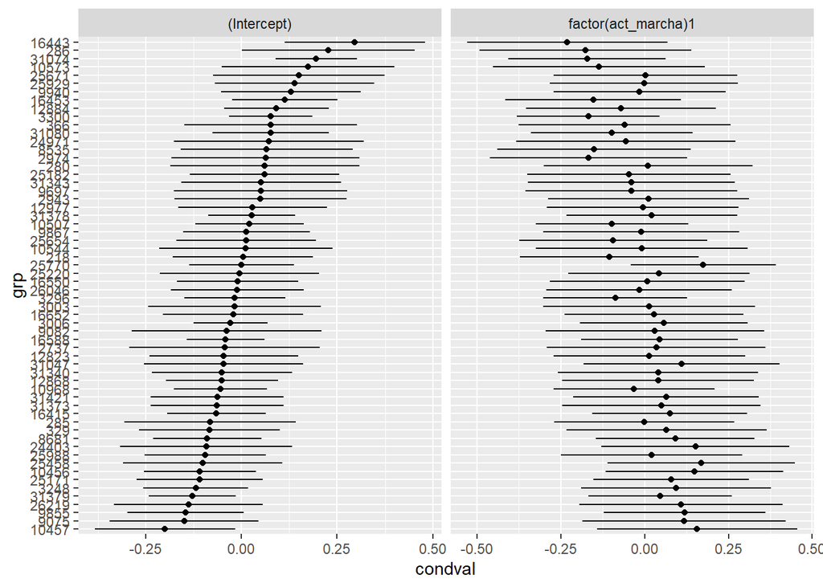

```r
if (require(ggplot2)) {
    ggplot(dd, aes(y=grp,x=condval)) +
        geom_point() + facet_wrap(~term,scales="free_x") +
        geom_errorbarh(aes(xmin=condval -2*condsd,
                           xmax=condval +2*condsd), height=0)
}
```

Evaluación de pendiente aleatoria de “Educación de los padres”: según el resultado del *loglikelihood ratio test* la pendiente entre educación e intención de participación no-disruptiva NO es aleatoria a trávez de las escuelas (p=0,898). Considerando este resultado, no se evalúa la interacción entre niveles.

```r
#Hipótesis 5 - Interacción entre variables de nivel 1 (educación y libros) con variables de nivel 2 (apertura y actividades cívicas)

# Modelo con Socialización política indirecta liberada
n7 <- lmer(nodisruptivo ~ 1  + conversacion + factor(act_marcha)  + educ_apod + pad_libros + civico_gc + meancivico + apertura_gc + meanap + factor(region) + factor(dependencia) + factor(sexo) + (1 + educ_apod |RBDE), data_red)
```

```
## boundary (singular) fit: see ?isSingular
```

```r
anova(n4, n7)
```

```
## refitting model(s) with ML (instead of REML)
```

```
## Data: data_red
## Models:
## n4: nodisruptivo ~ 1 + conversacion + factor(act_marcha) + pad_libros +
## n4:     educ_apod + civico_gc + meancivico + apertura_gc + meanap +
## n4:     factor(region) + factor(dependencia) + factor(sexo) + (1 |
## n4:     RBDE)
## n7: nodisruptivo ~ 1 + conversacion + factor(act_marcha) + educ_apod +
## n7:     pad_libros + civico_gc + meancivico + apertura_gc + meanap +
## n7:     factor(region) + factor(dependencia) + factor(sexo) + (1 +
## n7:     educ_apod | RBDE)
##    npar    AIC    BIC  logLik deviance  Chisq Df Pr(>Chisq)
## n4   20 222.78 308.01 -91.391   182.78
## n7   29 236.59 360.18 -89.298   178.59 4.1865  9     0.8987
```

```r
# Modelo con socialización política indirecta liberada con interacción con actividades cívicas
#m7a <- lmer(formal ~ 1  + conversacion + voto_apod   + educ_apod + pad_libros + civico_gc + meancivico + apertura_gc + meanap + factor(region) + factor(dependencia) + factor(sexo) + educ_apod * meanap + (1 + educ_apod |RBDE), data_red)

# Modelo con socialización política indirecta liberada con interacción con apertura a la discusión
#m7b <- lmer(formal ~ 1  + conversacion + voto_apod   + educ_apod + pad_libros + civico_gc + meancivico + apertura_gc + meanap + factor(region) + factor(dependencia) + factor(sexo) + educ_apod * meancivico + (1 + educ_apod |RBDE), data_red)

#skim(data_red$conversacion)

#screenreg(list(n4, n7), custom.model.names = c("n4", "n7"))
```

Evaluación de pendiente aleatoria de “Libros en el hogar”: según el resultado del *loglikelihood ratio test* la pendiente entre libros e intención de participación no-disruptiva NO es aleatoria a trávez de las escuelas (p=0,996). Considerando este resultado, no se evalúa la interacción entre niveles

```r
#Hipótesis 5 - Interacción entre variables de nivel 1 (educación y libros) con variables de nivel 2 (apertura y actividades cívicas)

# Modelo con Socialización política indirecta liberada
n8 <- lmer(nodisruptivo ~ 1  + conversacion + factor(act_marcha) + educ_apod + pad_libros + civico_gc + meancivico + apertura_gc + meanap + factor(region) + factor(dependencia) + factor(sexo) + (1 + pad_libros |RBDE), data_red)
```

```
## boundary (singular) fit: see ?isSingular
```

```r
anova(n4, n8)
```

```
## refitting model(s) with ML (instead of REML)
```

```
## Data: data_red
## Models:
## n4: nodisruptivo ~ 1 + conversacion + factor(act_marcha) + pad_libros +
## n4:     educ_apod + civico_gc + meancivico + apertura_gc + meanap +
## n4:     factor(region) + factor(dependencia) + factor(sexo) + (1 |
## n4:     RBDE)
## n8: nodisruptivo ~ 1 + conversacion + factor(act_marcha) + educ_apod +
## n8:     pad_libros + civico_gc + meancivico + apertura_gc + meanap +
## n8:     factor(region) + factor(dependencia) + factor(sexo) + (1 +
## n8:     pad_libros | RBDE)
##    npar    AIC    BIC  logLik deviance  Chisq Df Pr(>Chisq)
## n4   20 222.78 308.01 -91.391   182.78
## n8   29 239.15 362.73 -90.572   181.15 1.6374  9      0.996
```

```r
# Modelo con socialización política indirecta liberada con interacción con actividades cívicas
#m7a <- lmer(formal ~ 1  + conversacion + voto_apod   + educ_apod + pad_libros + civico_gc + meancivico + apertura_gc + meanap + factor(region) + factor(dependencia) + factor(sexo) + pad_libros * meanap + (1 + educ_apod |RBDE), data_red)

# Modelo con socialización política indirecta liberada con interacción con apertura a la discusión
#m7b <- lmer(formal ~ 1  + conversacion + voto_apod   + educ_apod + pad_libros + civico_gc + meancivico + apertura_gc + meanap + factor(region) + factor(dependencia) + factor(sexo) + pad_libros * meancivico + (1 + educ_apod |RBDE), data_red)

#skim(data_red$conversacion)

#screenreg(list(n4, n7), custom.model.names = c("n4", "n8"))
```

# Tabla con interacciones significativas

```r
stargazer(list(n1a, n1b, n2a, n2b, n3a, n3b, n4, n6a), type="html", title= "Tabla 3: Modelos para participación no-disruptiva", style = "default", covariate.labels = c("Conversación", "Familia marchó", "11 a 25 libros(vs menos de 10)", "26 a 100 libros(vs menos de 10)", "100 o más libros(vs menos de 10)", "Ed. Media (vs Básica)", "Ed. Técnica (vs Básica)", "Ed. Universitaria (vs Básica)", "Actividades cívicas(centrada)", "Actividades cívicas(promedio)", "Apertura a discusión(centrada)", "Apertura a discusión(promedio)", "Maule (vs Antofagasta)", "RM (vs Antofagasta)", "Subvencionado(vs Público)", "Privado(vs Público)", "Niña", "Familia marchó x apertura(mean)"),
          dep.var.caption  = "Indicador de Participación no-disruptiva",
          dep.var.labels   = "", digits= 2,
          star.char = c("+", "*", "**", "***"),
          star.cutoffs = c(0.1, 0.05, 0.01, 0.001),
          notes = c("+ p<=0.1; * p<=0.05; ** p<=0.01; *** p<0.001"),
          notes.append = F,
          column.labels = c("Conversación", "Familia marchó", "libros","Educación", "Actividades cívicas", "Apertura a disucusión", "completo", "Crosslevel int"), model.numbers          = FALSE)
```

**Tabla 3: Modelos para participación no-disruptiva**

Indicador de Participación no-disruptiva

Conversación

Familia marchó

libros

Educación

Actividades cívicas

Apertura a disucusión

completo

Crosslevel int

Conversación

0.08***

0.07***

0.07***

(0.02)

(0.02)

(0.02)

Familia marchó

0.09**

0.09*

-0.98*

(0.04)

(0.04)

(0.44)

11 a 25 libros(vs menos de 10)

0.03

0.02

0.02

(0.04)

(0.04)

(0.04)

26 a 100 libros(vs menos de 10)

0.05

0.04

0.04

(0.04)

(0.04)

(0.04)

100 o más libros(vs menos de 10)

0.09<sup>+</sup>

0.07

0.07

(0.05)

(0.05)

(0.05)

Ed. Media (vs Básica)

0.05

0.04

0.03

(0.05)

(0.04)

(0.04)

Ed. Técnica (vs Básica)

0.08

0.07

0.06

(0.05)

(0.05)

(0.05)

Ed. Universitaria (vs Básica)

0.06

0.01

0.01

(0.06)

(0.06)

(0.06)

Actividades cívicas(centrada)

0.03***

0.02**

0.02**

(0.01)

(0.01)

(0.01)

Actividades cívicas(promedio)

0.01

0.02

0.01

(0.02)

(0.03)

(0.02)

Apertura a discusión(centrada)

0.04<sup>+</sup>

0.01

0.01

(0.02)

(0.02)

(0.02)

Apertura a discusión(promedio)

-0.03

-0.09

-0.14

(0.08)

(0.08)

(0.09)

Maule (vs Antofagasta)

0.06

0.05

0.05

0.04

0.03

0.05

0.05

0.06

(0.07)

(0.07)

(0.07)

(0.07)

(0.07)

(0.07)

(0.07)

(0.07)

RM (vs Antofagasta)

0.05

0.03

0.04

0.03

0.03

0.04

0.04

0.06

(0.06)

(0.06)

(0.06)

(0.06)

(0.06)

(0.06)

(0.06)

(0.06)

Subvencionado(vs Público)

-0.02

-0.02

-0.02

-0.02

-0.01

-0.01

-0.02

-0.03

(0.05)

(0.05)

(0.05)

(0.05)

(0.05)

(0.05)

(0.05)

(0.05)

Privado(vs Público)

-0.05

-0.01

-0.04

-0.04

-0.02

-0.01

-0.03

-0.07

(0.07)

(0.07)

(0.07)

(0.07)

(0.07)

(0.07)

(0.07)

(0.07)

Niña

-0.04

-0.06*

-0.06*

-0.06*

-0.06*

-0.06<sup>+</sup>

-0.05<sup>+</sup>

-0.05<sup>+</sup>

(0.03)

(0.03)

(0.03)

(0.03)

(0.03)

(0.03)

(0.03)

(0.03)

Familia marchó x apertura(mean)

0.34*

(0.14)

Constant

-0.16*

0.04

0.02

0.01

0.01

0.14

0.004

0.18

(0.07)

(0.06)

(0.06)

(0.07)

(0.11)

(0.24)

(0.24)

(0.26)

Observations

524

524

524

524

524

524

524

524

Log Likelihood

-119.33

-124.72

-131.08

-131.47

-126.40

-128.73

-136.57

-132.67

Akaike Inf. Crit.

256.65

267.44

284.17

284.95

272.80

277.46

313.14

311.34

Bayesian Inf. Crit.

295.01

305.79

331.04

331.83

315.42

320.08

398.37

409.35

*Note:*

- p<=0.1; * p<=0.05; ** p<=0.01; *** p<0.001

# Tabla con sólo modelos completos (H1, H2 y H3)

```r
stargazer(list(m4, n4, d4), type="html", title= "Tabla: Modelos Finales para los tres tipos de Participación", style = "default", covariate.labels = c("Conversación", "Familia votó", "Familia marchó", "11 a 25 libros(vs menos de 10)", "26 a 100 libros(vs menos de 10)", "100 o más libros(vs menos de 10)", "Ed. Media (vs Básica)", "Ed. Técnica (vs Básica)", "Ed. Universitaria (vs Básica)", "Actividades cívicas(centrada)", "Actividades cívicas(promedio)", "Apertura a discusión(centrada)", "Apertura a discusión(promedio)", "Maule (vs Antofagasta)", "RM (vs Antofagasta)", "Subvencionado(vs Público)", "Privado(vs Público)", "Niña"),
          dep.var.caption  = "Indicadores de Participación",
          dep.var.labels   = c("", "", ""), digits= 2,
          star.char = c("+", "*", "**", "***"),
          star.cutoffs = c(0.1, 0.05, 0.01, 0.001),
          notes = c("+ p<=0.1; * p<=0.05; ** p<=0.01; *** p<0.001"),
          notes.append = F,
          column.labels = c("Formal", "No Disruptiva", "Disruptiva"), model.numbers= FALSE)
```

**Tabla: Modelos Finales para los tres tipos de Participación**

Indicadores de Participación

Formal

No Disruptiva

Disruptiva

Conversación

0.17***

0.07***

0.07*

(0.03)

(0.02)

(0.03)

Familia votó

0.16***

(0.04)

Familia marchó

0.09*

0.16*

(0.04)

(0.07)

11 a 25 libros(vs menos de 10)

0.04

0.06

(0.07)

(0.04)

(0.09)

26 a 100 libros(vs menos de 10)

0.22**

0.07

0.06

(0.07)

(0.05)

(0.10)

100 o más libros(vs menos de 10)

0.17*

0.01

-0.03

(0.08)

(0.06)

(0.11)

Ed. Media (vs Básica)

0.01

0.02

0.03

(0.06)

(0.04)

(0.08)

Ed. Técnica (vs Básica)

0.05

0.04

0.05

(0.06)

(0.04)

(0.07)

Ed. Universitaria (vs Básica)

0.08

0.07

0.09

(0.07)

(0.05)

(0.09)

Actividades cívicas(centrada)

0.03**

0.02**

0.03<sup>+</sup>

(0.01)

(0.01)

(0.01)

Actividades cívicas(promedio)

0.002

0.02

0.03

(0.03)

(0.03)

(0.05)

Apertura a discusión(centrada)

0.02

0.01

0.02

(0.03)

(0.02)

(0.04)

Apertura a discusión(promedio)

0.07

-0.09

-0.23

(0.09)

(0.08)

(0.16)

Maule (vs Antofagasta)

0.04

0.05

0.08

(0.07)

(0.07)

(0.14)

RM (vs Antofagasta)

-0.08

0.04

0.13

(0.07)

(0.06)

(0.12)

Subvencionado(vs Público)

0.05

-0.02

-0.06

(0.05)

(0.05)

(0.10)

Privado(vs Público)

0.12

-0.03

-0.14

(0.08)

(0.07)

(0.15)

Niña

-0.04

-0.05<sup>+</sup>

-0.09<sup>+</sup>

(0.04)

(0.03)

(0.05)

Constant

-1.10***

0.004

0.42

(0.26)

(0.24)

(0.48)

Observations

524

524

524

Log Likelihood

-342.26

-136.57

-470.59

Akaike Inf. Crit.

724.52

313.14

981.19

Bayesian Inf. Crit.

809.75

398.37

1,066.42

*Note:*

- p<=0.1; * p<=0.05; ** p<=0.01; *** p<0.001